# Project: Investigate a Dataset - [No-show Appointments]

- Introduction
- Data Wrangling
- Exploratory Data Analysis
- Conclusions
- Limitations

## Introduction

### Dataset Description

> This dataset collects information from 100k medical appointments in Brazil and is focused on the question of whether or not patients show up for their appointment.

> In this notebook we will be analysing this dataset for people how are above 16 years old only.

### Data Dictionary

> The order of columns listed here is different from the original dataset order.
> - * refers to newly added columns during the wrangling process.
> - ** refers to columns that were dropped during the wrangling process.
- **Gender** : Male or Female
- **Age** : How old is the patient
- **Neighbourhood** : Where the appointment takes place, "Where the hospital is within the city of Vitória"
- **AppointmentDay** : The day of the actuall appointment, when they have to visit the doctor.
- * **WaitingDays**
  - Number of days a person have waited before the Appointment
  - `AppointmentDay - ScheduledDay`
- **Scholarship** : Indicates whether or not the patient is enrolled in Brasilian welfare program [Bolsa Família](https://en.wikipedia.org/wiki/Bolsa_Fam%C3%ADlia)
- **Hipertension** : True or False
- **Diabetes** : True or False
- **Alcoholism** : True or False
- **Handcap** : the number of desabilites a person has.
- **SMS_received**
  - True or False
  - indecates that 1 or more messages sent to the patient.
- **No_how**
  - ‘No’ if the patient showed up to their appointment
  - ‘Yes’ if they did not show up.
- PatientId** : Identification of a patient
- AppointmentID** : Identification of each appointment
- ScheduledDay** : The date in which someone registered the appointment

### Question of Analysis

1. What is the absence ratio generally, and for each gender?
2. What is the effect of each disease on the Absence Ratio?
3. What is Absence Ratio for people who received SMS ant those who didn't?
4. What is Absence Ratio for people with specefic characteristics?
   1. Patients with Hypertension, Diabetes and Handicap.
   2. Patients received SMS and having scholarship.
   3. Patients waited more than one day.
   4. Patients who have their appointments at the same day.
5. How does the absence rate change over the course of the week?
6. What is the correlation between Absence Ratio and the following factors?
   - Age
   - Waiting Days
7. For neighbourhoods hosted most of the appointments, what is the relation between Absence Ratio and number of hosted appointments?

## Data Wrangling

> Lets have a broad look to our dataset to see if it needs any trimming or cleaning.

### Loading and Assessing

> By loading our dataset and looking into it, we will discover some problems that need to be solved before starting our analysis, then we will solve those problems in the cleaning process.

```python
import numpy as np
import pandas as pd
import matplotlib.pyplot as plt

pd.options.display.max_rows = 99
%matplotlib inline
```

**Calling** the necessary packages that includes some useful functions we will use in the next sections.

- **NumPy:** adding support for large, multi-dimensional arrays and matrices, along with a large collection of high-level mathematical functions to operate on these arrays.
- **Pandas:** providing fast, flexible, and expressive data structures designed to make working with "relational" or "labeled" data both easy and intuitive.
- **Matplotlib:** generating plots, histograms, bar charts, and other types of charts with just a few lines of code.

```python
df= pd.read_csv('Database_No_show_appointments/noshowappointments-kagglev2-may-2016.csv')
df.rename(columns={'No-show':'No_show' },inplace=True)
df.head()
```

|  | PatientId | AppointmentID | Gender | ScheduledDay | AppointmentDay | Age | Neighbourhood | Scholarship | Hipertension | Diabetes | Alcoholism | Handcap | SMS_received | No_show |
| --- | --- | --- | --- | --- | --- | --- | --- | --- | --- | --- | --- | --- | --- | --- |
| 0 | 2.987250e+13 | 5642903 | F | 2016-04-29T18:38:08Z | 2016-04-29T00:00:00Z | 62 | JARDIM DA PENHA | 0 | 1 | 0 | 0 | 0 | 0 | No |
| 1 | 5.589978e+14 | 5642503 | M | 2016-04-29T16:08:27Z | 2016-04-29T00:00:00Z | 56 | JARDIM DA PENHA | 0 | 0 | 0 | 0 | 0 | 0 | No |
| 2 | 4.262962e+12 | 5642549 | F | 2016-04-29T16:19:04Z | 2016-04-29T00:00:00Z | 62 | MATA DA PRAIA | 0 | 0 | 0 | 0 | 0 | 0 | No |
| 3 | 8.679512e+11 | 5642828 | F | 2016-04-29T17:29:31Z | 2016-04-29T00:00:00Z | 8 | PONTAL DE CAMBURI | 0 | 0 | 0 | 0 | 0 | 0 | No |
| 4 | 8.841186e+12 | 5642494 | F | 2016-04-29T16:07:23Z | 2016-04-29T00:00:00Z | 56 | JARDIM DA PENHA | 0 | 1 | 1 | 0 | 0 | 0 | No |

> **Reading** the content of our data scource using Pandas and assigning it to a Pandas DataFrame, and viewing its first 5 entries to check if it's loaded correctly.

> **Observation**
> - some columns names need a little change
> - *ScheduledDay* provides informations about time in seconds, while *AppointmentDay* provides the date only without the time of the appointment.

```python
def more_about(df):
    """Makes a table of some useful informations for a given Dataframe"""

    columns = [df.dtypes, df.count(), df.isnull().sum(), df.nunique()]
    names   = ["data_type", "n_values",      "n_NaN",      "n_unique"]
    infos   = pd.concat(columns, axis=1, keys=names)

    return infos

more_about(df)
```

|  | data_type | n_values | n_NaN | n_unique |
| --- | --- | --- | --- | --- |
| PatientId | float64 | 110527 | 0 | 62299 |
| AppointmentID | int64 | 110527 | 0 | 110527 |
| Gender | object | 110527 | 0 | 2 |
| ScheduledDay | object | 110527 | 0 | 103549 |
| AppointmentDay | object | 110527 | 0 | 27 |
| Age | int64 | 110527 | 0 | 104 |
| Neighbourhood | object | 110527 | 0 | 81 |
| Scholarship | int64 | 110527 | 0 | 2 |
| Hipertension | int64 | 110527 | 0 | 2 |
| Diabetes | int64 | 110527 | 0 | 2 |
| Alcoholism | int64 | 110527 | 0 | 2 |
| Handcap | int64 | 110527 | 0 | 5 |
| SMS_received | int64 | 110527 | 0 | 2 |
| No_show | object | 110527 | 0 | 2 |

> **Extracting** general useful informations about data type, number of null values and number of unique values for each column.

> **Observation**
> - The dataset contains zero null values.
> - *ScheduledDay* and *AppointmentDay* need to be Date type.
> - all of *AppointmentId* values are unique so this column isn't needed in our investigation.

```python
df.duplicated().sum()
```

```
0
```

> **Observation** The dataset contains no duplicates.

```python
df.describe()
```

|  | PatientId | AppointmentID | Age | Scholarship | Hipertension | Diabetes | Alcoholism | Handcap | SMS_received |
| --- | --- | --- | --- | --- | --- | --- | --- | --- | --- |
| count | 1.105270e+05 | 1.105270e+05 | 110527.000000 | 110527.000000 | 110527.000000 | 110527.000000 | 110527.000000 | 110527.000000 | 110527.000000 |
| mean | 1.474963e+14 | 5.675305e+06 | 37.088874 | 0.098266 | 0.197246 | 0.071865 | 0.030400 | 0.022248 | 0.321026 |
| std | 2.560949e+14 | 7.129575e+04 | 23.110205 | 0.297675 | 0.397921 | 0.258265 | 0.171686 | 0.161543 | 0.466873 |
| min | 3.921784e+04 | 5.030230e+06 | -1.000000 | 0.000000 | 0.000000 | 0.000000 | 0.000000 | 0.000000 | 0.000000 |
| 25% | 4.172614e+12 | 5.640286e+06 | 18.000000 | 0.000000 | 0.000000 | 0.000000 | 0.000000 | 0.000000 | 0.000000 |
| 50% | 3.173184e+13 | 5.680573e+06 | 37.000000 | 0.000000 | 0.000000 | 0.000000 | 0.000000 | 0.000000 | 0.000000 |
| 75% | 9.439172e+13 | 5.725524e+06 | 55.000000 | 0.000000 | 0.000000 | 0.000000 | 0.000000 | 0.000000 | 1.000000 |
| max | 9.999816e+14 | 5.790484e+06 | 115.000000 | 1.000000 | 1.000000 | 1.000000 | 1.000000 | 4.000000 | 1.000000 |

> **Observation** The min age is -1.

```python
print(np.sort(df.Age.unique()))
```

```
[ -1   0   1   2   3   4   5   6   7   8   9  10  11  12  13  14  15  16
  17  18  19  20  21  22  23  24  25  26  27  28  29  30  31  32  33  34
  35  36  37  38  39  40  41  42  43  44  45  46  47  48  49  50  51  52
  53  54  55  56  57  58  59  60  61  62  63  64  65  66  67  68  69  70
  71  72  73  74  75  76  77  78  79  80  81  82  83  84  85  86  87  88
  89  90  91  92  93  94  95  96  97  98  99 100 102 115]
```

```python
df[df.Age == -1]
```

|  | PatientId | AppointmentID | Gender | ScheduledDay | AppointmentDay | Age | Neighbourhood | Scholarship | Hipertension | Diabetes | Alcoholism | Handcap | SMS_received | No_show |
| --- | --- | --- | --- | --- | --- | --- | --- | --- | --- | --- | --- | --- | --- | --- |
| 99832 | 4.659432e+14 | 5775010 | F | 2016-06-06T08:58:13Z | 2016-06-06T00:00:00Z | -1 | ROMÃO | 0 | 0 | 0 | 0 | 0 | 0 | No |

> **Observation** There is only one entry with age of -1

> For the ages in my opinion, a baby or a child is not the one who decides whether to go for the appointment or not, in most cases for a person under 16 years old showing up for the appointment is related to other persons as well (mostly his parents), so we will analyse our data for adults above 16 years old only

### Data Cleaning

> Now let's take actions for the observations above.

#### Renaming Columns

**Action** Renaming misspelled columns to explain data correctly and unify all the names under one formatting.

```python
df.rename(columns={'Hipertension':'Hypertension',
                   'Handcap': 'Handicap',
                   'No-show':'No_show',},inplace=True)
```

#### Fixing date problems

> **Actions**
> - Changing *ScheduledDay* and *AppointmentDay* to be Date type and to cotain informations about the date only without the time.
> - Making new column to hold informations about number of waiting days *WaitingDays* = `(AppointmentDay - ScheduledDay)`
> - Changing the informations in *AppointmentDay* to the name of the day instead of the date.

```python
df['ScheduledDay']   = pd.to_datetime(pd.to_datetime(df['ScheduledDay']).dt.date)
df['AppointmentDay'] = pd.to_datetime(df['AppointmentDay'])

df["WaitingDays"]    = (df['AppointmentDay'] - df['ScheduledDay']).dt.days

df['AppointmentDay'] = df['AppointmentDay'].dt.day_name()
```

```python
df[df.WaitingDays < 0]
```

|  | PatientId | AppointmentID | Gender | ScheduledDay | AppointmentDay | Age | Neighbourhood | Scholarship | Hypertension | Diabetes | Alcoholism | Handicap | SMS_received | No_show | WaitingDays |
| --- | --- | --- | --- | --- | --- | --- | --- | --- | --- | --- | --- | --- | --- | --- | --- |
| 27033 | 7.839273e+12 | 5679978 | M | 2016-05-10 | Monday | 38 | RESISTÊNCIA | 0 | 0 | 0 | 0 | 1 | 0 | Yes | -1 |
| 55226 | 7.896294e+12 | 5715660 | F | 2016-05-18 | Tuesday | 19 | SANTO ANTÔNIO | 0 | 0 | 0 | 0 | 1 | 0 | Yes | -1 |
| 64175 | 2.425226e+13 | 5664962 | F | 2016-05-05 | Wednesday | 22 | CONSOLAÇÃO | 0 | 0 | 0 | 0 | 0 | 0 | Yes | -1 |
| 71533 | 9.982316e+14 | 5686628 | F | 2016-05-11 | Thursday | 81 | SANTO ANTÔNIO | 0 | 0 | 0 | 0 | 0 | 0 | Yes | -6 |
| 72362 | 3.787482e+12 | 5655637 | M | 2016-05-04 | Tuesday | 7 | TABUAZEIRO | 0 | 0 | 0 | 0 | 0 | 0 | Yes | -1 |

> **Observation** Some persons waited a negative number of days.

#### Dropping

> **Actions**
> - drop unnecessary columns and order the other columns.
> - drop observed rows that contain typos.
> - trim rows according to age to be for people above 16 years old.

```python
df= df[['Gender','Age','Neighbourhood','AppointmentDay','WaitingDays',
        'Scholarship','Hypertension','Diabetes','Alcoholism','Handicap',
        'SMS_received', 'No_show']]

df= df.query('WaitingDays >= 0 and Age >= 16')

df.head()
```

|  | Gender | Age | Neighbourhood | AppointmentDay | WaitingDays | Scholarship | Hypertension | Diabetes | Alcoholism | Handicap | SMS_received | No_show |
| --- | --- | --- | --- | --- | --- | --- | --- | --- | --- | --- | --- | --- |
| 0 | F | 62 | JARDIM DA PENHA | Friday | 0 | 0 | 1 | 0 | 0 | 0 | 0 | No |
| 1 | M | 56 | JARDIM DA PENHA | Friday | 0 | 0 | 0 | 0 | 0 | 0 | 0 | No |
| 2 | F | 62 | MATA DA PRAIA | Friday | 0 | 0 | 0 | 0 | 0 | 0 | 0 | No |
| 4 | F | 56 | JARDIM DA PENHA | Friday | 0 | 0 | 1 | 1 | 0 | 0 | 0 | No |
| 5 | F | 76 | REPÚBLICA | Friday | 2 | 0 | 1 | 0 | 0 | 0 | 0 | No |

```python
more_about(df)
```

|  | data_type | n_values | n_NaN | n_unique |
| --- | --- | --- | --- | --- |
| Gender | object | 86054 | 0 | 2 |
| Age | int64 | 86054 | 0 | 87 |
| Neighbourhood | object | 86054 | 0 | 81 |
| AppointmentDay | object | 86054 | 0 | 6 |
| WaitingDays | int64 | 86054 | 0 | 127 |
| Scholarship | int64 | 86054 | 0 | 2 |
| Hypertension | int64 | 86054 | 0 | 2 |
| Diabetes | int64 | 86054 | 0 | 2 |
| Alcoholism | int64 | 86054 | 0 | 2 |
| Handicap | int64 | 86054 | 0 | 5 |
| SMS_received | int64 | 86054 | 0 | 2 |
| No_show | object | 86054 | 0 | 2 |

## Exploratory Data Analysis

### What factors are more correlated with the patient not showing up for their appointment?

> Here we will take every single factor and see how much its affecting the attendence of the patients, there will be a repeatitive code blocks so its better to handle some of them with custom functions.

> **Research Question 1 (What is the absence ratio generally, and for each gender?)**

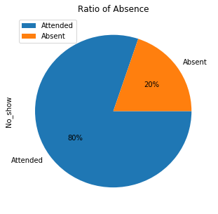

```
No     68987
Yes    17067
Name: No_show, dtype: int64
```

```python
df.No_show.value_counts().plot(kind= 'pie',  labels = ['Attended', 'Absent'],
                               figsize=(5, 5), counterclock = False, autopct='%1.0f%%')

plt.title('Ratio of Absence')
plt.legend()
plt.show()
df.No_show.value_counts()
```

> **Observation** General Absence Ratio is 20%

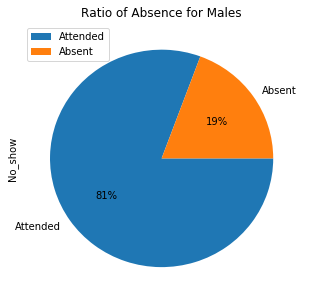

```
No     21112
Yes     5068
Name: No_show, dtype: int64
```

```python
values=df[df.Gender == "M"].No_show.value_counts()

values.plot(kind= 'pie',  labels = ['Attended', 'Absent'],
            figsize=(5, 5), counterclock = False, autopct='%1.0f%%')
plt.title('Ratio of Absence for Males')
plt.legend()
plt.show()
values
```

> **Observation** Males Absence Ratio is 19%

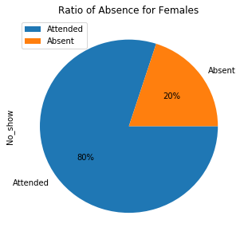

```
No     47875
Yes    11999
Name: No_show, dtype: int64
```

```python
values=df[df.Gender == "F"].No_show.value_counts()

values.plot(kind= 'pie',  labels = ['Attended', 'Absent'],
            figsize=(5, 5), counterclock = False, autopct='%1.0f%%')
plt.title('Ratio of Absence for Females')
plt.legend()
plt.show()

values
```

> **Observation** Females Absence Ratio is 20%

> **Research Question 2 (What is the effect of each disease on the Absence Ratio?)**

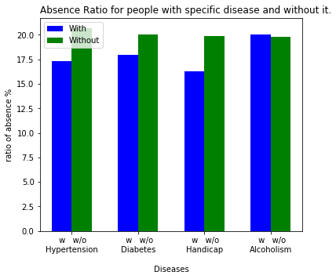

|  | disease | with | without |
| --- | --- | --- | --- |
| 0 | Hypertension | 17.284291 | 20.696361 |
| 1 | Diabetes | 17.952279 | 20.023550 |
| 2 | Handicap | 16.281513 | 19.912363 |
| 3 | Alcoholism | 20.011965 | 19.825658 |

```python
ratio = pd.DataFrame()
diseases = ['Hypertension','Diabetes','Handicap','Alcoholism']
for disease in diseases:
    total  = df[disease].value_counts()
    absent = df.query('No_show == "Yes"')[disease].value_counts()
    ratio = ratio.append({'disease': disease,
                          'with': (absent*100/total).loc[1],
                          'without': (absent*100/total).loc[0]}, ignore_index=True)

i = np.arange(len(ratio))
b = 0.3
plt.subplots(figsize=(i[-1]+3,5))
plt.bar(i  , ratio['with']   , color = 'b', width = b, label='With')
plt.bar(i+b, ratio['without'], color = 'g', width = b, label='Without')
plt.xticks(i+b/2,' w   w/o\n'+ratio.disease)

plt.title("Absence Ratio for people with specific disease and without it.",loc='left')
plt.xlabel("\nDiseases")
plt.ylabel("ratio of absence %")
plt.legend()
plt.show()
ratio
```

> **Observation**
> - Absence Ratio for patients with Hypertension is 17.3%, and 20.7% for those without it
> - Absence Ratio for patients with Diabetes is 18%, and 20% for those without it
> - Absence Ratio for patients with Handicap is 16.3%, and 19.9% for those without it

> **Research Question 3 (What is Absence Ratio for people who received SMS ant those who didn't?)**

```
0    0.163149
1    0.270157
Name: SMS_received, dtype: float64
```

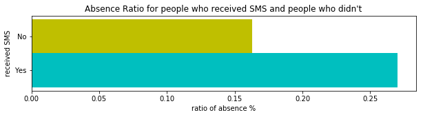

```python
total  = df.SMS_received.value_counts()
absent = df.query('No_show == "Yes"').SMS_received.value_counts()
ratio  = absent/total
print(ratio)

b = 0.2
plt.subplots(figsize=(10,2))
plt.barh(0, ratio.loc[1], color = 'c', height=b)
plt.barh(b, ratio.loc[0], color = 'y', height=b)
plt.yticks([0,b],['Yes','No'])
plt.title("Absence Ratio for people who received SMS and people who didn't")
plt.xlabel("ratio of absence %")
plt.ylabel("received SMS")
plt.show()
```

> **Observation**
> - Absence Ratio for patients who received an SMS is 27%, and 16.3% for those who didn't receive any.

> **Research Question 4 (What is Absence Ratio for patients with specefic characteristics?)**

> ```
> A. Patients with Hypertension, Diabetes and Handicap.
> B. Patients received SMS and having scholarship.
> C. Patients waited more than one day.
> D. Patients who have their appointments at the same day.
> ```

```python
def combo_effect(factors):
    """
    For patients with certain characteristics combined
    how much percent showed up and how much absent?

    **REQUIRED Packages** pandas and matplotlib

    Arguments: list with one or more than one factor as strings.

    Outputs: a pie showing their absence rate
    """
    q_string = ''
    for factor in factors:
        q_string += factor + ' >= 1 and '
    q_string = q_string[:-4]

    matchs = df.query(q_string).No_show.value_counts()
    matchs.plot(kind= 'pie', labels = ['Attended', 'Absent'],
                figsize=(5, 5), counterclock = False, autopct='%1.0f%%')

    msg = str(matchs.sum()) +' patients meet this characteristics\n'
    print(msg,matchs)
```

```
358 patients meet this characteristics
 No     303
Yes     55
Name: No_show, dtype: int64
```

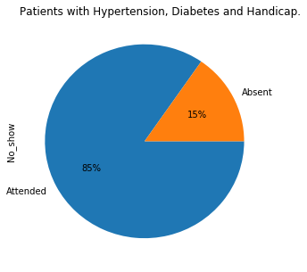

```python
combo_effect(['Hypertension','Diabetes','Handicap'])
plt.title("Patients with Hypertension, Diabetes and Handicap.", loc='left');
```

> **Observation**
> - Absence Ratio for patients with Hypertension, Diabetes and Handicap is 15%

```
2740 patients meet this characteristics
 No     1804
Yes     936
Name: No_show, dtype: int64
```

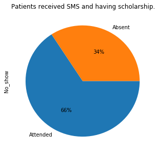

```python
combo_effect(['SMS_received','Scholarship'])
plt.title("Patients received SMS and having scholarship.", loc='left');
```

> **Observation**
> - Absence Ratio for patients received SMS and having scholarship is 34%

```
57528 patients meet this characteristics
 No     41602
Yes    15926
Name: No_show, dtype: int64
```

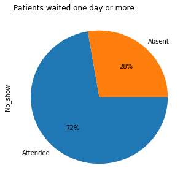

```python
combo_effect(['WaitingDays'])
plt.title("Patients waited one day or more.", loc='left');
```

> **Observation**
> - Absence Ratio for patients waited one day or more is 28%

```
28526 patients meet this characteristics
 No     27385
Yes     1141
Name: No_show, dtype: int64
```

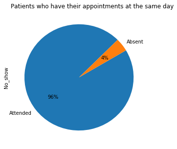

```python
matchs = df.query('WaitingDays == 0').No_show.value_counts()
matchs.plot(kind= 'pie', labels = ['Attended', 'Absent'],
            figsize=(5, 5), startangle = 45, autopct='%1.0f%%')
plt.title("Patients who have their appointments at the same day", loc='left')

msg = str(matchs.sum()) +' patients meet this characteristics\n'
print(msg,matchs)
```

> **Observation**
> - Absence Ratio for patients who have their appointments at the same day is 4%

> **Research Question 5 (How does the absence rate change over the course of the week?)**

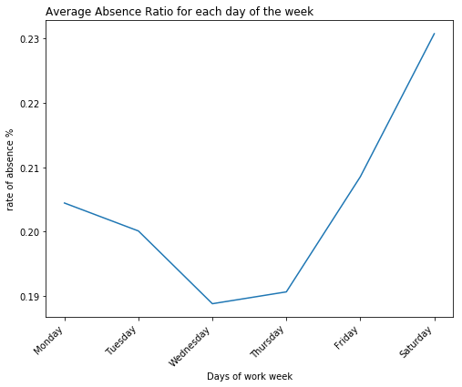

```
Monday       0.204453
Tuesday      0.200109
Wednesday    0.188801
Thursday     0.190642
Friday       0.208533
Saturday     0.230769
Name: AppointmentDay, dtype: float64
```

```python
days=['Monday', 'Tuesday', 'Wednesday', 'Thursday','Friday','Saturday']
days_not = df.query('No_show == "Yes"').AppointmentDay.value_counts()
days_tot = df.AppointmentDay.value_counts()
proportion = days_not/days_tot

x= np.arange(len(days))
plt.figure(figsize= (8,6))
plt.plot(x, proportion[days])
plt.xticks(x, days, rotation=45, horizontalalignment='right')

plt.title("Average Absence Ratio for each day of the week",loc='left')
plt.ylabel("rate of absence %")
plt.xlabel("Days of work week")
plt.show()
proportion[days]
```

> **Observation**
> - Absence Ratio is lower in the middle of the week.
> - lowest average Absence Ratio is 18.9% in Wednesdays.
> - Highest average Absence Ratio is 23.1% in Saturdays.

> **Research Question 6 (What is the correlation between Absence Ratio and the following factors?)**
> - Age
> - Number of waiting days

```python
def factor_box(factor):
    """
    box plot showing the distribution of the given factor according to No_show column.
    """
    df.boxplot(column = factor, by= 'No_show', rot=0,figsize=(5,8))
    plt.title('Distribution of '+factor)
    plt.xlabel('Person is Absent?')
    plt.ylabel(factor)


def factor_scatter(factor):
    """
    scatter plot to show the correlation between the given factor and Absence Ratio
    """
    ratio = df.query('No_show == "Yes"')[factor].value_counts()/df[factor].value_counts()
    i = np.array(ratio.index)
    plt.subplots(figsize=(10,5))
    plt.scatter(x = i , y = ratio.loc[i], color='darkorange')
    plt.xticks(range(0,len(i)+50,10))
    plt.title("Correlation between Absence Ratio and "+factor)
    plt.ylabel("Absence Ratio")
    plt.xlabel(factor)
    plt.show()
```

| No_show | count | mean | std | min | 25% | 50% | 75% | max |
| --- | --- | --- | --- | --- | --- | --- | --- | --- |
| No | 68987.0 | 46.635062 | 18.197023 | 16.0 | 32.0 | 47.0 | 60.0 | 115.0 |
| Yes | 17067.0 | 42.729302 | 17.962758 | 16.0 | 28.0 | 41.0 | 56.0 | 115.0 |

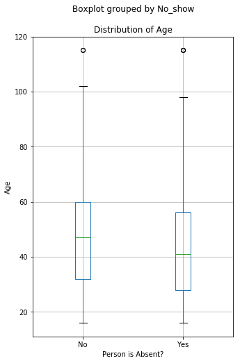

```python
factor_box("Age")
pd.DataFrame(df.groupby(['No_show']).Age.describe())
```

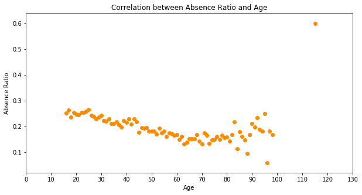

|  | count | mean | std | min | 25% | 50% | 75% | max |
| --- | --- | --- | --- | --- | --- | --- | --- | --- |
| Age | 86054.0 | 45.860436 | 18.217391 | 16.0 | 31.0 | 45.0 | 59.0 | 115.0 |

```python
factor_scatter("Age")
pd.DataFrame(df.Age.describe()).transpose()
```

> **Observation**
> - There is a negative correlation between Absence Ratio and Age.

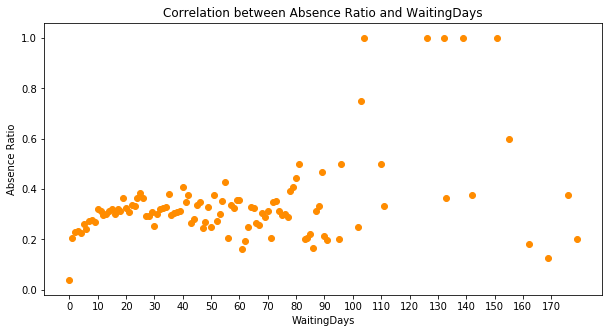

|  | count | mean | std | min | 25% | 50% | 75% | max |
| --- | --- | --- | --- | --- | --- | --- | --- | --- |
| WaitingDays | 86054.0 | 10.320159 | 15.64358 | 0.0 | 0.0 | 4.0 | 15.0 | 179.0 |

```python
factor_scatter("WaitingDays")
pd.DataFrame(df.WaitingDays.describe()).transpose()
```

> **Observation**
> - There is a positive correlation between Absence Ratio and WaitingDays for waiting days from 1 to 30 days, and for Waiting days more than 30 the correlation is hard to figure out.

```python
hosts = df.Neighbourhood.value_counts()
count = hosts.sum()
indices = hosts.index

top_hosts = []
top_count = 0
i = 0

while top_count < count/2 :
    host = indices[i]
    top_hosts.append(host)
    top_count = hosts[top_hosts].sum()
    i +=1

other_hosts = hosts.drop(top_hosts).index

print('top', len(top_hosts), 'hosted', hosts[top_hosts].sum(), 'appointments')
print('all', len(indices), 'neighbourhoods hosted', hosts.sum(), 'appointments')
hosts.head()
```

```
top 16 hosted 43538 appointments
all 81 neighbourhoods hosted 86054 appointments
```

```
JARDIM CAMBURI     6491
MARIA ORTIZ        4333
JARDIM DA PENHA    3482
RESISTÊNCIA        3299
CENTRO             2850
Name: Neighbourhood, dtype: int64
```

> **Action** aquiring the neighbourhoods that hosted most of the appointments (more than 50%)

> **Observation** 16 ot of 81 neighbourhoods hosted 50,6% of all the appointments

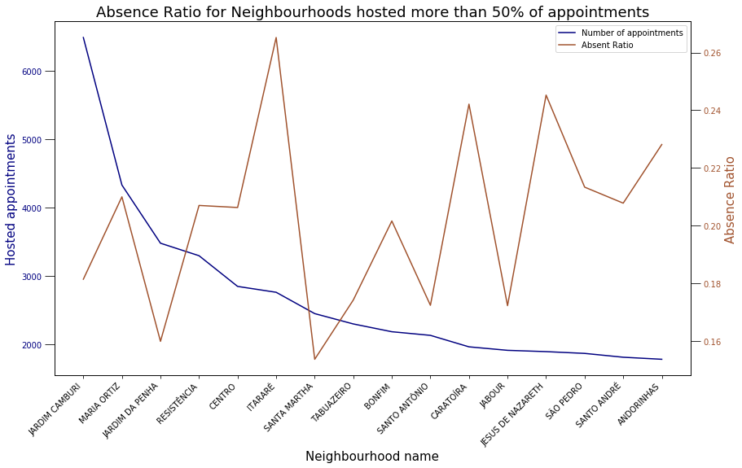

```python
hosts_absent = df.query('No_show == "Yes"').Neighbourhood.value_counts()
hosts_ratio = hosts_absent/hosts
x = np.arange(len(top_hosts))


fig, ax1 = plt.subplots(figsize=(14,8))

ax1.set_xlabel('Neighbourhood name',fontsize = 15)
ax1.set_ylabel('Hosted appointments', color = 'navy', fontsize = 15)
plot_1 = ax1.plot(x , hosts[top_hosts], color = 'navy', label = "Number of appointments")
ax1.tick_params(axis ='y', labelcolor = 'navy', size = 12)
plt.xticks(x, top_hosts, rotation=45, horizontalalignment='right')


ax2 = ax1.twinx()

ax2.set_ylabel('Absence Ratio', color = 'sienna', fontsize = 15)
plot_2 = ax2.plot(x , hosts_ratio[top_hosts], color = 'sienna', label = "Absent Ratio")
ax2.tick_params(axis ='y', labelcolor = 'sienna', size = 12)


lns = plot_1 + plot_2
labels = [l.get_label() for l in lns]
plt.legend(lns, labels, loc=0)
plt.title("Absence Ratio for Neighbourhoods hosted more than 50% of appointments",size=18)
plt.show()
```

> **Observation**
> - There is no relation between Absence Ratio and number of hosted appointments.

## Conclusions

> **What is the absence ratio generally, and for each gender?**
> - General Absence Ratio is 20%
> - Females Absence Ratio is 20%
> - Males Absence Ratio is 19%

> **What is the effect of each disease on the Absence Ratio?**
> - Absence Ratio for patients with Hypertension is 17.3%, and 20.7% for those without it
> - Absence Ratio for patients with Diabetes is 18%, and 20% for those without it
> - Absence Ratio for patients with Handicap is 16.3%, and 19.9% for those without it

> **What is Absence Ratio for people who received SMS ant those who didn't?**
> - Absence Ratio for patients who received an SMS is 27%, and 16.3% for those who didn't receive any.

> **What is Absence Ratio for people with specefic characteristics?**
> - Absence Ratio for patients with Hypertension, Diabetes and Handicap is 15%
> - Absence Ratio for patients received SMS and having scholarship is 34%
> - Absence Ratio for patients waited one day or more is 28%
> - Absence Ratio for patients who have their appointments at the same day is 4%

> **How does the absence rate change over the course of the week?**
> - Absence Ratio is lower in the middle of the week.
> - lowest average Absence Ratio is 18.9% in Wednesdays.
> - Highest average Absence Ratio is 23.1% in Saturdays.

> **What is the correlation between Absence Ratio and the following factors?**
> - **Age:** there is a negative correlation between Absence Ratio and Age.
> - **Waiting days:** there is a positive correlation between Absence Ratio and WaitingDays for waiting days from 1 to 30 days, and for Waiting days more than 30 the correlation is hard to figure out.

> **For neighbourhoods hosted most of the appointments, what is the relation between Absence Ratio and number of hosted appointments?**
> - 16 ot of 81 neighbourhoods hosted 50,6% of all the appointments
> - There is no relation between Absence Ratio and number of hosted appointments.

## Limitations

**Population**

> Brazil had an estimated population of 215 Million in 2022, with a 0.7% growth rate, according to IBGE (Instituto Brasileiro de Geografia e Estatistica). Brazil is the seventh most populous country in the world.

> Vitória, the city from which the data were collected, had an estimated population of 369k according to IBGE, and the city is the capital of the state of Espírito Santo.

> This dataset collects informations from 100k medical appointments and after wrangling our dataset the number reduced to be 86k appointments, this number is only 0.04% of Brasil population, and 23% of Vitória population.

**Time**

> The data covers a short time period with olny 3 months, and there is no information about the appointment time during the day.

**Locations**

> Some neighbourhoods have higher absence rate than others, this might depend in other factors such as the distance from the patient's home to the hospital, the avilability of transport, the level of service in that neighbourhood, and all this imformations is missed.